# Seq2seq Transformers for Word Generation

Seq2seq models are designed to learn the mapping between an input sequence and a target output sequence, making them ideal for tasks where structured input data is transformed into a related output sequence. These models capture complex relationships between sequential data, allowing them to generate coherent and contextually relevant sequences based on an input. Seq2seq models have been widely applied in natural language processing tasks such as language translation, where a model translates sentences from one language to another, text summarization, where it condenses long text into key points, and question-answering, where the model generates responses based on provided input questions.

The Transformer model, a breakthrough in seq2seq architectures, introduced a new approach to handling long-range dependencies within sequences using a mechanism called self-attention. Unlike traditional recurrent neural networks (RNNs) or long short-term memory (LSTM) models, which process sequences sequentially, the Transformer model processes all positions in the sequence in parallel, enabling it to capture global context more effectively and significantly reducing training time. This self-attention mechanism allows the model to focus on different parts of the input sequence with varying degrees of importance, dynamically adjusting to each input and providing a better understanding of context.

With these capabilities, Transformer-based seq2seq models have become the backbone of many modern applications. For instance, models like BERT, GPT, and T5, built on the Transformer architecture, have advanced the state of the art in machine translation, chatbots, summarization, and even code generation.

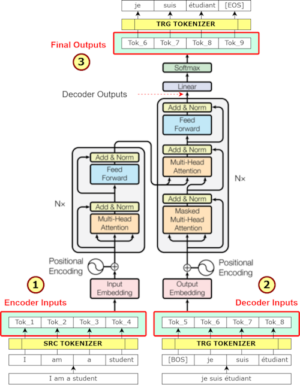

0_Transformer_src_trg.png

# Translation

Translation converts a sequence of text from one language to another. In this tutorial, we aim to use and fine-tune the Transformer model T5 (Text-To-Text Transfer Transformer) for English-to-French translation. T5, a seq2seq model, is particularly well-suited for translation tasks due to its ability to handle complex language structures and retain contextual meaning.

A Transformer model like T5 is trained by predicting the next word in a sequence based on the context of preceding words, learning to generate coherent and contextually accurate translations word-by-word.

This tutorial will show you how to:

1. Finetune [T5](https://huggingface.co/t5-small) on the English-French subset of the [OPUS Books](https://huggingface.co/datasets/opus_books) dataset to translate English text to French.
2. Use the finetuned model for inference.

**Please run this notebook on Google Colab with GPU support enabled.**

```python
# Library installation
! pip install transformers datasets evaluate sacrebleu
```

## Load OPUS Books (English - French) dataset

Start by loading the English-French subset of the [OPUS Books](https://huggingface.co/datasets/opus_books) dataset:

```python
from datasets import load_dataset

books = load_dataset("opus_books", "en-fr")
```

```python
print(books)
```

```
DatasetDict({
    train: Dataset({
        features: ['id', 'translation'],
        num_rows: 127085
    })
})
```

The dataset we downloaded only includes training data, with no separate test set provided. To address this, we used the train_test_split method to split the data into training and testing sets ourselves:

```python
# books = books["train"].train_test_split(train_size = 0.8, test_size=0.2) # Train: 80% Test: 20%

# Due to time constraints, we’re using just 10% of the data for training to speed up the process.
# We allocate 10% of the data for training and 5% for testing, leaving the remaining samples unused.
books = books["train"].train_test_split(train_size = 0.1, test_size=0.05)
```

```python
print(books)
```

```
DatasetDict({
    train: Dataset({
        features: ['id', 'translation'],
        num_rows: 12708
    })
    test: Dataset({
        features: ['id', 'translation'],
        num_rows: 6355
    })
})
```

Then take a look at an example:

```python
books["train"][0]
```

```
{'id': '62042',
 'translation': {'en': 'From time to time, he followed a fine stone with his eye, and when it did good execution, he said, "Hum!"',
  'fr': 'De temps en temps il suivait une belle pierre de l’œil, et, quand elle tuait bien, il disait : « Hun ! »'}}
```

`translation`: an English and French translation of the text.

## Preprocess

The next step is to load a T5 tokenizer to process the English-French language pairs. A tokenizer converts raw text into smaller units called tokens (like words or subwords) and encodes them into numerical representations that the model can understand.

```python
from transformers import AutoTokenizer

checkpoint = "t5-small" # Use a pre-trained tokenizer
tokenizer = AutoTokenizer.from_pretrained(checkpoint)
```

The preprocessing function you want to create needs to:

1. Prefix the input with a prompt so T5 knows this is a translation task. Some models capable of multiple NLP tasks require prompting for specific tasks.
2. Tokenize the input (English) and target (French) separately because you can’t tokenize French text with a tokenizer pretrained on an English vocabulary.
3. Truncate sequences to be no longer than the maximum length set by the `max_length` parameter.

```python
source_lang = "en"
target_lang = "fr"
prefix = "translate English to French: "


def preprocess_function(examples):
    inputs = [prefix + example[source_lang] for example in examples["translation"]]
    targets = [example[target_lang] for example in examples["translation"]]
    model_inputs = tokenizer(inputs, text_target=targets, max_length=128, truncation=True)
    return model_inputs
```

To apply the preprocessing function over the entire dataset, use Datasets map method. You can speed up the `map` function by setting `batched=True` to process multiple elements of the dataset at once:

```python
tokenized_books = books.map(preprocess_function, batched=True)
```

Now create a batch of examples using DataCollatorForSeq2Seq. It’s more efficient to *dynamically pad* the sentences to the longest length in a batch during collation, instead of padding the whole dataset to the maximum length.

```python
from transformers import DataCollatorForSeq2Seq

data_collator = DataCollatorForSeq2Seq(tokenizer=tokenizer, model=checkpoint)
```

## Train

Our goal is to fine-tune a pre-trained T5 model for English-to-French translation. Fine-tuning allows us to adapt the model’s existing language knowledge to our specific task, improving its translation quality on the dataset we’re using. We start by loading the pre-trained T5 model, which already has a strong foundation in language patterns, and then fine-tune it on our English-French language pairs to further enhance its performance for our needs.

```python
from transformers import AutoModelForSeq2SeqLM, Seq2SeqTrainingArguments, Seq2SeqTrainer

model = AutoModelForSeq2SeqLM.from_pretrained(checkpoint)
```

To fine-tune the model, just three steps remain:

```python
training_args = Seq2SeqTrainingArguments(
    output_dir="CSC413_opus_books_model",
    evaluation_strategy="epoch",
    learning_rate=2e-5,
    per_device_train_batch_size=16,
    per_device_eval_batch_size=16,
    weight_decay=0.01,
    save_total_limit=3,
    num_train_epochs=1,
    predict_with_generate=True,
    fp16=True,
    push_to_hub=False,
    report_to="none"
)

trainer = Seq2SeqTrainer(
    model=model,
    args=training_args,
    train_dataset=tokenized_books["train"],
    eval_dataset=tokenized_books["test"],
    tokenizer=tokenizer,
    data_collator=data_collator,
)

training_results = trainer.train()
print(training_results)
```

[795/795 02:19, Epoch 1/1]

| Epoch | Training Loss | Validation Loss |
| --- | --- | --- |
| 1 | 2.110100 | 1.829962 |

```
TrainOutput(global_step=795, training_loss=2.0803384648928853, metrics={'train_runtime': 140.2121, 'train_samples_per_second': 90.634, 'train_steps_per_second': 5.67, 'total_flos': 312195471114240.0, 'train_loss': 2.0803384648928853, 'epoch': 1.0})
```

## Inference

Great, now that we hve finetuned a T5 model for English-French translation!

Come up with some text you’d like to translate to another language. For T5, you need to prefix your input depending on the task you’re working on. For translation from English to French, you should prefix your input as shown below:

```python
# text = "translate English to French: Legumes share resources with nitrogen-fixing bacteria."
text = "translate English to French: I'm a student at the University of Toronto and excited to dive into the amazing world of Deep Learning!"
```

Tokenize the text and return the `input_ids` as PyTorch tensors:

```python
from transformers import AutoTokenizer

tokenizer = AutoTokenizer.from_pretrained("CSC413_opus_books_model/checkpoint-{}".format(training_results.global_step))
inputs = tokenizer(text, return_tensors="pt").input_ids
```

Use the [generate()](https://huggingface.co/docs/transformers/main/en/main_classes/text_generation#transformers.GenerationMixin.generate) method to create the translation.

```python
from transformers import AutoModelForSeq2SeqLM

model = AutoModelForSeq2SeqLM.from_pretrained("CSC413_opus_books_model/checkpoint-{}".format(training_results.global_step))
outputs = model.generate(inputs, max_new_tokens=40, do_sample=True, top_k=30, top_p=0.95)
```

Decode the generated token ids back into text:

```python
tokenizer.decode(outputs[0], skip_special_tokens=True)
```

```
'Je suis une étudiante à l’Université de Toronto et exalté de plonger dans le monde merveilleux de Deep Learning.'
```